# oyolasigmaz506portfolio_week9

## 7.3.4 Exercises

1. Explore the distribution of each of the x, y, and z variables in diamonds. What do you learn? Think about a diamond and how you might decide which dimension is the length, width, and depth.

First, let’s visualize the three dimensions separately

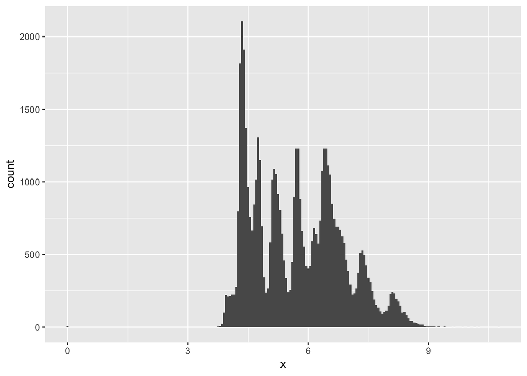

```r
ggplot(data = diamonds) +
  geom_histogram(mapping = aes(x = x), binwidth = 0.05)
```

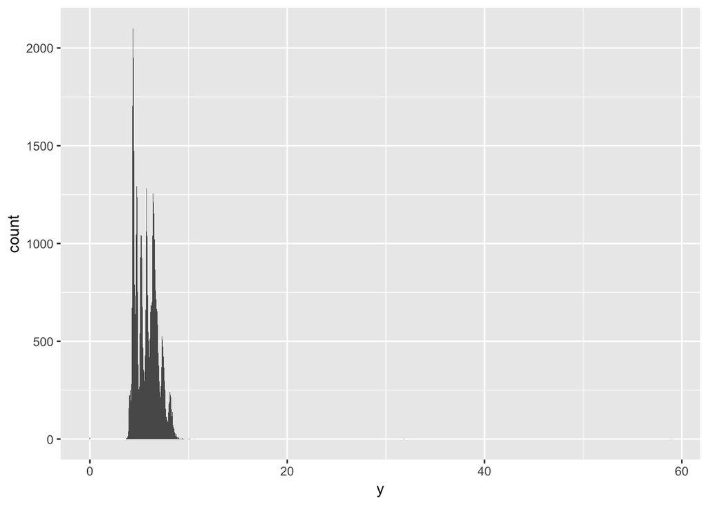

```r
ggplot(data = diamonds) +
  geom_histogram(mapping = aes(x = y), binwidth = 0.05)
```

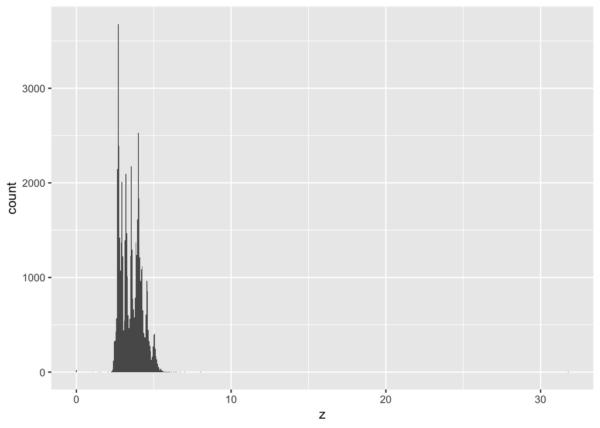

```r
ggplot(data = diamonds) +
  geom_histogram(mapping = aes(x = z), binwidth = 0.05)
```

2. Explore the distribution of price. Do you discover anything unusual or surprising? (Hint: Carefully think about the binwidth and make sure you try a wide range of values.)

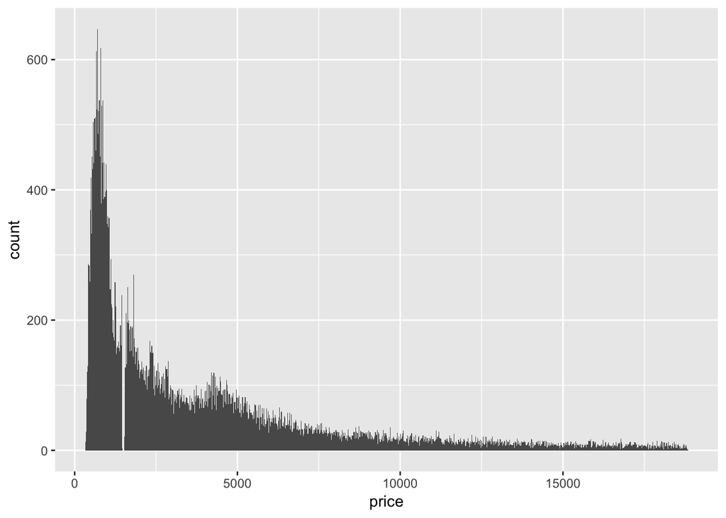

```r
ggplot(data = diamonds) +
  geom_histogram(mapping = aes(x = price), bins = 1000)
```

3. How many diamonds are 0.99 carat? How many are 1 carat? What do you think is the cause of the difference?

```r
diamonds %>% filter(carat == 0.99 | carat == 1.00) %>% group_by(carat) %>% summarise(n())
```

```
## # A tibble: 2 x 2
##   carat `n()`
##   <dbl> <int>
## 1  0.99    23
## 2  1     1558
```

We see many more that are 1.00 carat than 0.99. It is probably because the prices change when you hit 1.00 as opposed to staying below 1.00.

4. Compare and contrast coord_cartesian() vs xlim() or ylim() when zooming in on a histogram. What happens if you leave binwidth unset? What happens if you try and zoom so only half a bar shows?

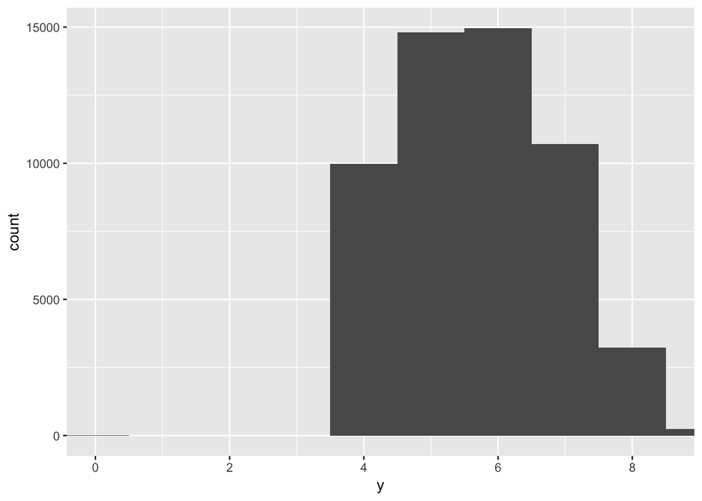

```r
ggplot(diamonds) +
  geom_histogram(mapping = aes(x = y), binwidth = 1) +
  coord_cartesian(xlim = c(0, 8.5))
```

Well, not much happens if only half a bar shows, but we need to keep in mind what our binwidth is while determining the limits of our plot, so that such a thing doesn’t happen.

## 7.4 Missing values

geom_point() #creates a plot for displaying all the data points.

We can create a variable that stores missing/NA values, and plot them separately:

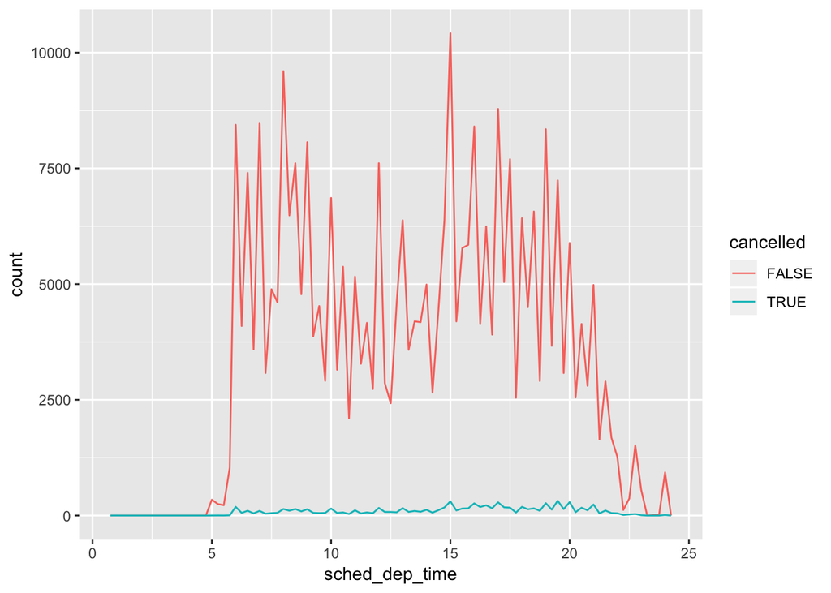

```r
flights %>%
  mutate(
    cancelled = is.na(dep_time),
    sched_hour = sched_dep_time %/% 100,
    sched_min = sched_dep_time %% 100,
    sched_dep_time = sched_hour + sched_min / 60
  ) %>%
  ggplot(mapping = aes(sched_dep_time)) +
    geom_freqpoly(mapping = aes(colour = cancelled), binwidth = 1/4)
```

### 7.4.1 Exercises

1. What happens to missing values in a histogram? What happens to missing values in a bar chart? Why is there a difference?

Let’s create some missing values, and then draw histograms and bar charts:

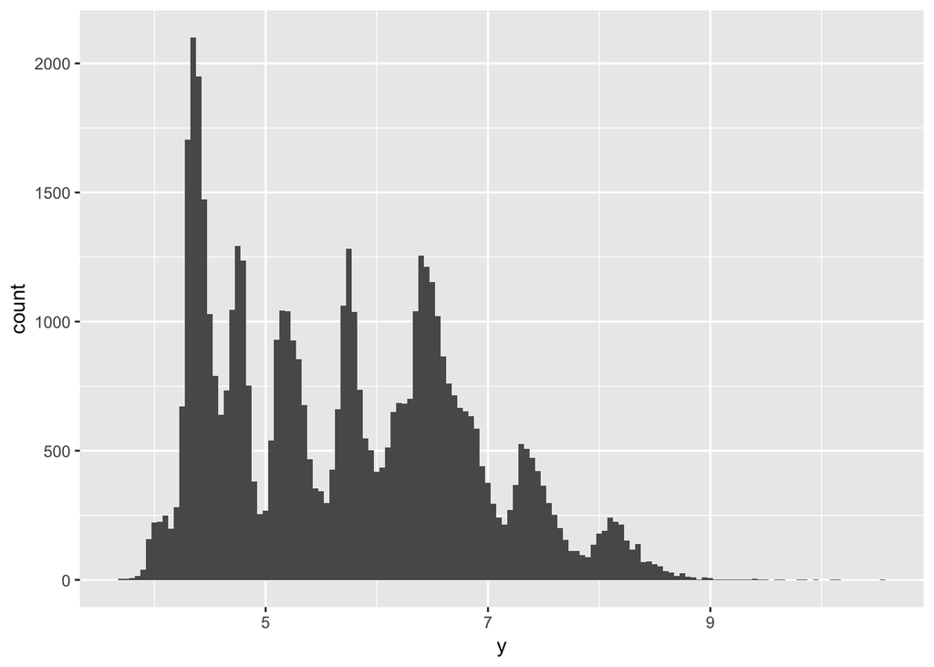

```r
diamonds2 <- diamonds %>%
  mutate(y = ifelse(y < 3 | y > 20, NA, y))

ggplot(data = diamonds2) +
  geom_histogram(mapping = aes(x = y), binwidth = 0.05)
```

In the histogram, the missing values are removed.

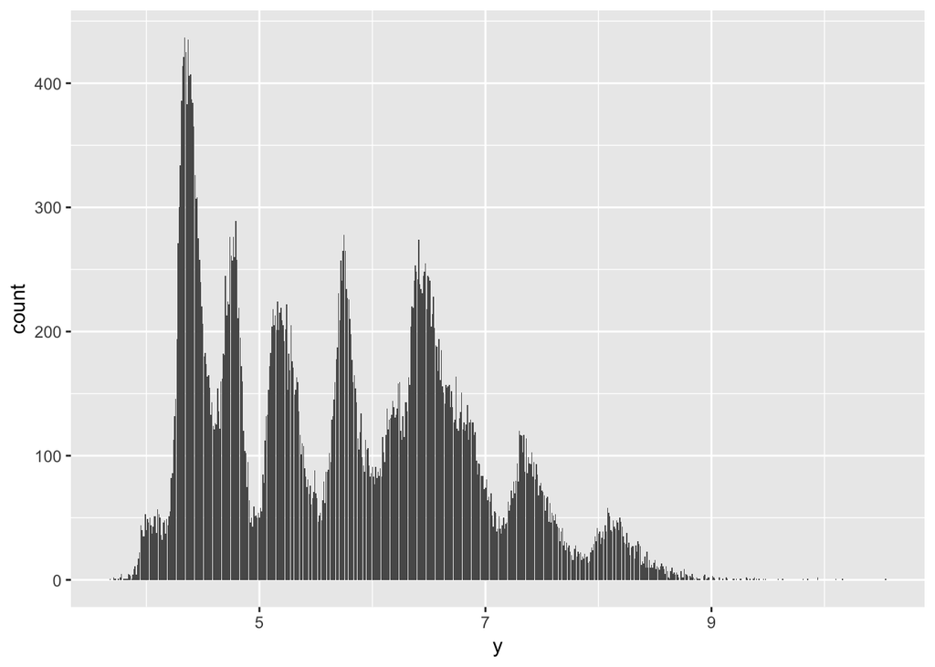

```r
ggplot(data = diamonds2) +
  geom_bar(mapping = aes(x = y))
```

Well it seems they were removed in bar plot too, so I’m not sure what the difference is.

2. What does na.rm = TRUE do in mean() and sum()?

It removes the NA values from being used as part of mean and sum.

## 7.5 Covariation

geom_boxplot() #draw a boxplot

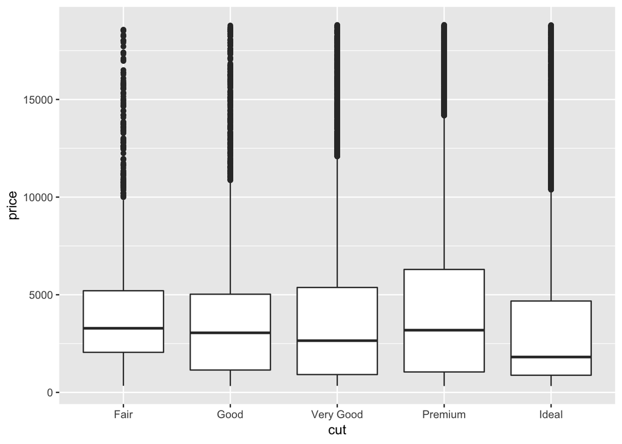

```r
ggplot(data = diamonds, mapping = aes(x = cut, y = price)) +
  geom_boxplot()
```

coord_flip() # allows us to flip the coordinates in a plot.

## 7.5.1.1 Exercises

1. Use what you’ve learned to improve the visualisation of the departure times of cancelled vs. non-cancelled flights.

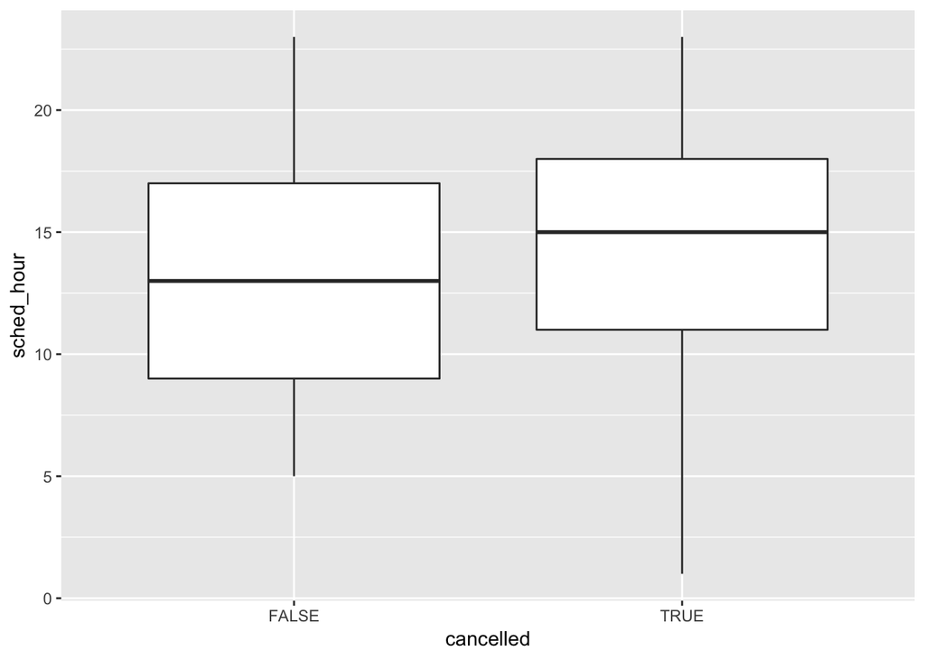

```r
flights %>%
  mutate(
    cancelled = is.na(dep_time),
    sched_hour = sched_dep_time %/% 100,
    sched_min = sched_dep_time %% 100,
    sched_dep_time = sched_hour + sched_min / 60
  ) %>%
  ggplot(mapping = aes(x=cancelled, y=sched_hour)) +
  geom_boxplot()
```

```r
#  ggplot(mapping = aes(sched_hour)) +
#    geom_freqpoly(mapping = aes(colour = cancelled), binwidth = 1/4)
```

We see that the flights that are cancelled are later in the day, usually.

2. What variable in the diamonds dataset is most important for predicting the price of a diamond? How is that variable correlated with cut? Why does the combination of those two relationships lead to lower quality diamonds being more expensive?

We know cut isn’t the most important, but let’s try color and clarity

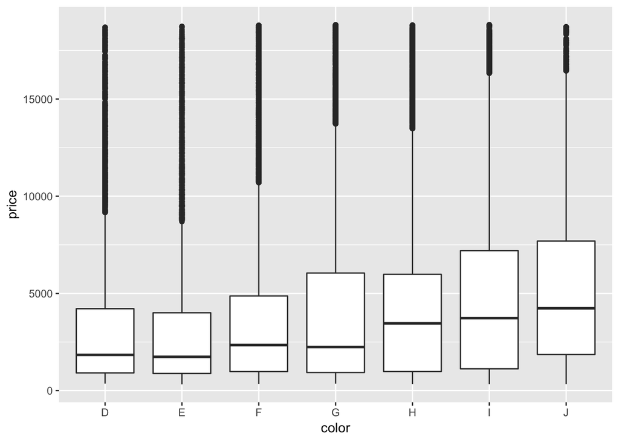

```r
ggplot(data = diamonds, mapping = aes(x = color, y = price)) +
  geom_boxplot()
```

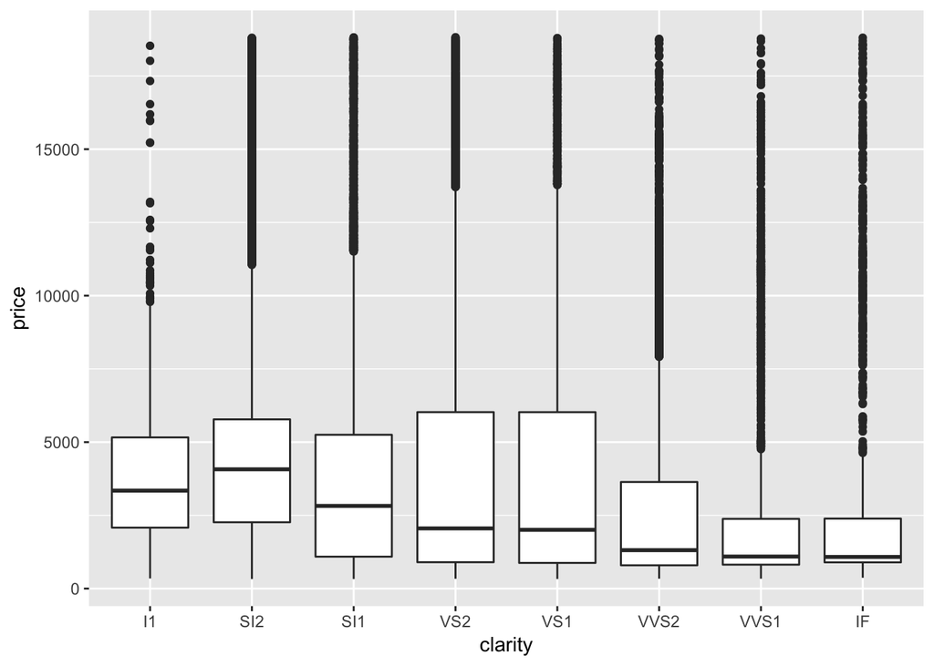

```r
ggplot(data = diamonds, mapping = aes(x = clarity, y = price)) +
  geom_boxplot()
```

3. Install the ggstance package, and create a horizontal boxplot. How does this compare to using coord_flip()?

[figure not shown]

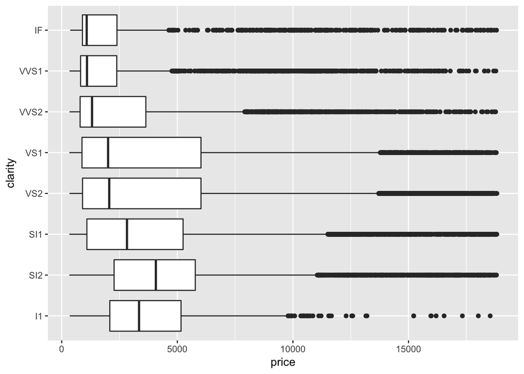

```r
ggplot(data = diamonds, mapping = aes(x = price, y = clarity)) +
  geom_boxploth()
```

Cannot notice much difference.

4. One problem with boxplots is that they were developed in an era of much smaller datasets and tend to display a prohibitively large number of “outlying values”. One approach to remedy this problem is the letter value plot. Install the lvplot package, and try using geom_lv() to display the distribution of price vs cut. What do you learn? How do you interpret the plots?

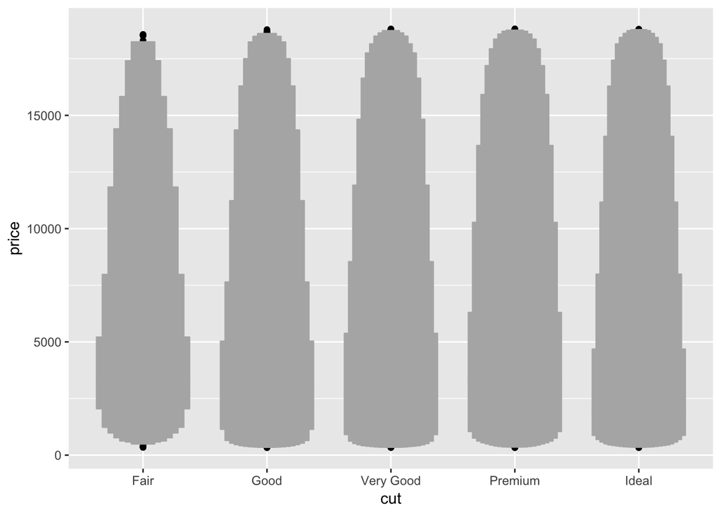

```r
ggplot(data = diamonds, mapping = aes(x = cut, y = price)) +
  geom_lv()
```

Here, the width of the boxes are where the larger portions of the values are. Here, we see that it is unlikely for a fair diamond to be expensive, when compared to other cuts, which is not necessarily as obvious from the boxplot.

## 7.5.2.1 Exercises

1. How could you rescale the count dataset above to more clearly show the distribution of cut within colour, or colour within cut?

We can scale the sizes:

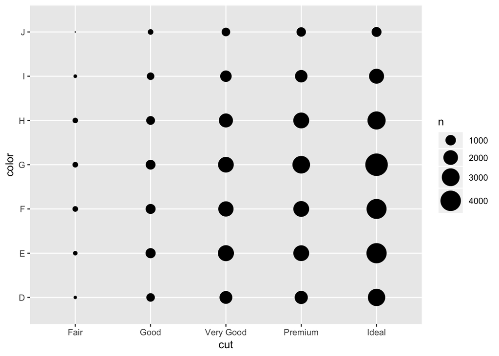

```r
ggplot(data = diamonds) +
  geom_count(mapping = aes(x = cut, y = color)) +
  scale_size_continuous(range = c(0, 10))
```

2. Use geom_tile() together with dplyr to explore how average flight delays vary by destination and month of year. What makes the plot difficult to read? How could you improve it?

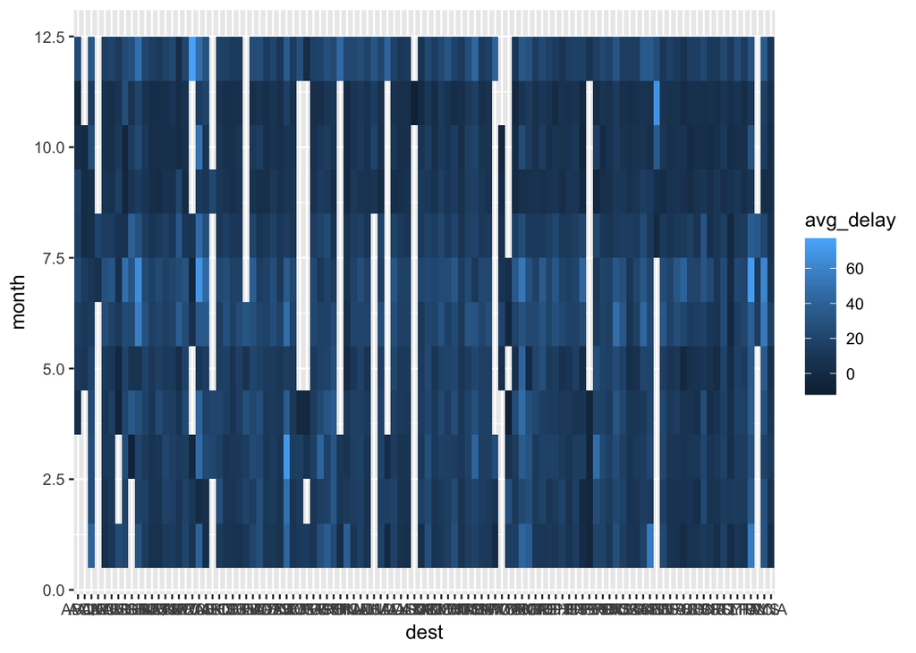

```r
flights %>%
  filter(!is.na(dep_delay)) %>%
  group_by(dest, month) %>%
  summarise(avg_delay = mean(dep_delay)) %>%
  ggplot(mapping = aes(x = dest, y = month)) +
  geom_tile(mapping = aes(fill = avg_delay))
```

This is almost unreadable as there are way too many destinations. We can improve it by using only the more important destinations

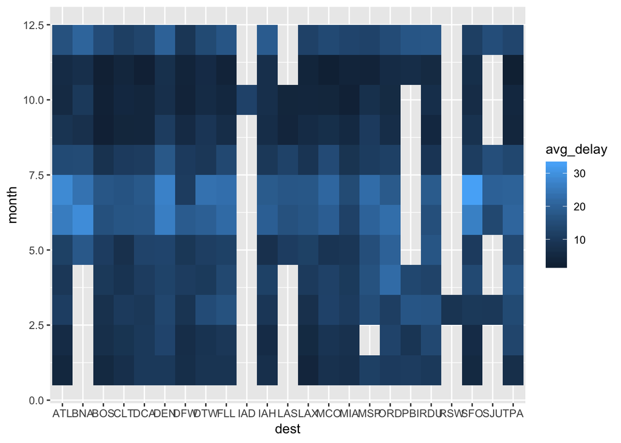

```r
flights %>%
  filter(!is.na(dep_delay)) %>%
  group_by(dest, month) %>%
  summarise(avg_delay = mean(dep_delay),
            total_flight = n()) %>%
  filter(total_flight > 500) %>%
  ggplot(mapping = aes(x = dest, y = month)) +
  geom_tile(mapping = aes(fill = avg_delay))
```

3. Why is it slightly better to use aes(x = color, y = cut) rather than aes(x = cut, y = color) in the example above?

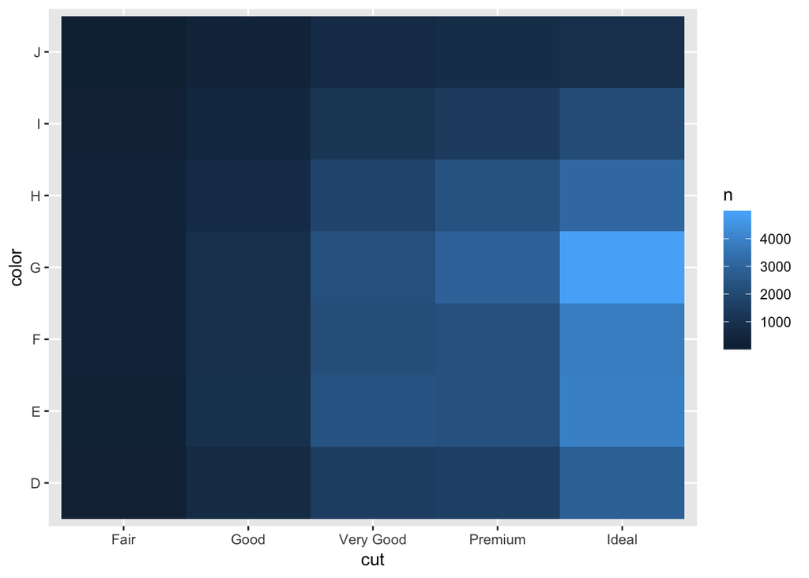

```r
diamonds %>%
  count(color, cut) %>%
  ggplot(mapping = aes(x = cut, y = color)) +
    geom_tile(mapping = aes(fill = n))
```

x = color and y = cut makes the tiles more square-like.